# v0.8

### Per Sequence GC Content

The average GC content of reads. Normal random library typically have a roughly normal distribution of GC content. See the [FastQC help](http://www.bioinformatics.babraham.ac.uk/projects/fastqc/Help/3%20Analysis%20Modules/5%20Per%20Sequence%20GC%20Content.html).

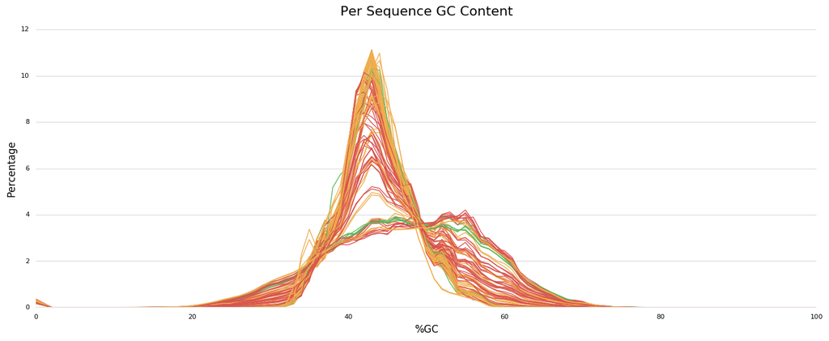

### Per Base N Content

The percentage of base calls at each position for which an N was called. See the [FastQC help](http://www.bioinformatics.babraham.ac.uk/projects/fastqc/Help/3%20Analysis%20Modules/6%20Per%20Base%20N%20Content.html).

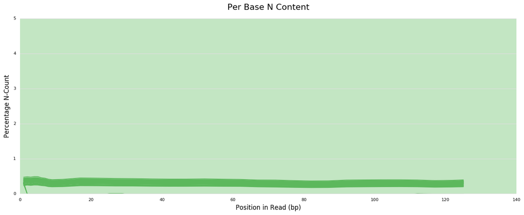

### Sequence Length Distribution

All samples have sequences of a single length (126bp).

### Sequence Duplication Levels

The relative level of duplication found for every sequence. See the [FastQC help](http://www.bioinformatics.babraham.ac.uk/projects/fastqc/Help/3%20Analysis%20Modules/8%20Duplicate%20Sequences.html).

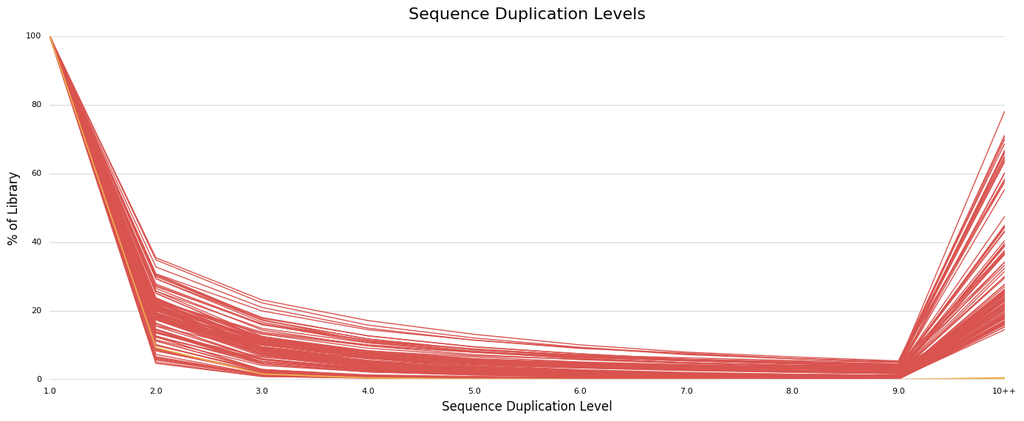

**[MultiQC v0.8](http://multiqc.info)** - Written by [Phil Ewels](http://phil.ewels.co.uk), available on [GitHub](https://github.com/ewels/MultiQC).

This report uses [HighCharts](http://www.highcharts.com/), [jQuery](https://jquery.com/), [jQuery UI](https://jqueryui.com/), [Bootstrap](http://getbootstrap.com/), chroma.js, FileSaver.js and [clipboard.js](https://clipboardjs.com/).